# HTC Analysis

Mickey Rafa

FallQ 2016 - SpringQ 2017

## Correlation Analysis of **trafpres** Component Variables

The default setting of the `cor_auto()` function is to produce a Pearson’s correlation matrix. However, if this function is fed binary or ordinal data, it will produce the polychoric correlation matrix. Given that our raw component data is comprised of binary data, a polychoric correlation matrix is required.

```r
#Build polychoric correlation matrix
trafpresCor <- qgraph::cor_auto(HTCdata %>% select(3:61), detectOrdinal = TRUE,
                        forcePD = FALSE)
```

```
Variables detected as ordinal: O_labor; O_childlabor; O_sex; O_childsex; O_cstourism; O_domestic; O_begging; T_labor; T_childlabor; T_sex; T_childsex; T_cstourism; T_domestic; T_begging; D_labor; D_childlabor; D_sex; D_childcse; D_cstourism; D_domestic; D_begging; I_labor; I_childlabor; I_sex; I_chi…
```

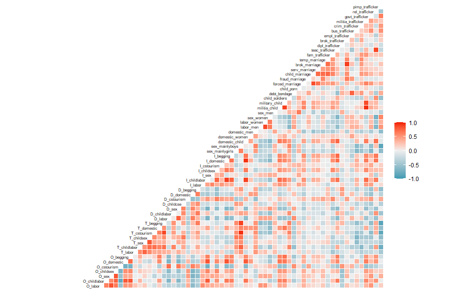

```r
#Show correlation matrix of off trafpres component variables
GGally::ggcorr(trafpresCor, hjust=1.1, layout.exp=10, size=2, label_alpha=.3)
```

This bird’s eye view illustrates that there are some variables of these 59 **trafpres** components that are highly correlated with one another. These coefficients could be used in confirmatory factor analysis (CFA) to determine whether the theorized indices within the dataset seem to cluster. Before experimenting with CFA, we’ll experiment with principal components analysis (PCA) as a dimension reduction and index building technique.

These data are complex to analyze together. Some variables, such as **pimp_trafficker** are very commonly coded (1,833), while other variables, like **sex_mainlyboys** are rarely used (only 6 times total in the dataset). With a dataset this unbalanced, PCA will artificially use the uncommon variables to find orthoganals.

| variable | Number of Occurrences |
| --- | --- |
| T_cstourism | 4 |
| sex_mainlyboys | 6 |
| T_begging | 11 |
| child_soldiers | 21 |
| child_porn | 24 |
| I_cstourism | 26 |
| T_childlabor | 34 |
| domestic_men | 35 |
| serv_marriage | 55 |
| T_domestic | 57 |

[output cut: 8 more lines]

```r
vars_greater_than_100 <- HTCdata %>%
  gather(variable, value, 3:61) %>%
  group_by(variable) %>%
  summarise(sum_value = sum(value)) %>%
  arrange(sum_value) %>%
  filter(sum_value > 100) %>%
  select(variable) %>%
  unique()
HTCdata_v2 <- HTCdata %>%
  group_by(country, year) %>%
  select(c(vars_greater_than_100$variable)) %>%
  ungroup()
```

## Fit all vars for sub-indices and total HTI

```r
#Build polychoric correlation matrix
#ALL VARS
trafpresCor_pca_apr18 <- qgraph::cor_auto(HTCdata_v2 %>% select(3:42),
                                          detectOrdinal = TRUE, forcePD = FALSE)
```

```
Variables detected as ordinal: O_begging; O_cstourism; teac_trafficker; militia_trafficker; militia_child; T_labor; sex_mainlygirls; D_begging; forced_marriage; child_marriage; D_childlabor; T_sex; D_cstourism; empl_trafficker; O_childlabor; O_domestic; fam_trafficker; domestic_women; debt_bondage; …
```

[output not shown]

```
Parallel analysis suggests that the number of factors =  NA  and the number of components =  5
```

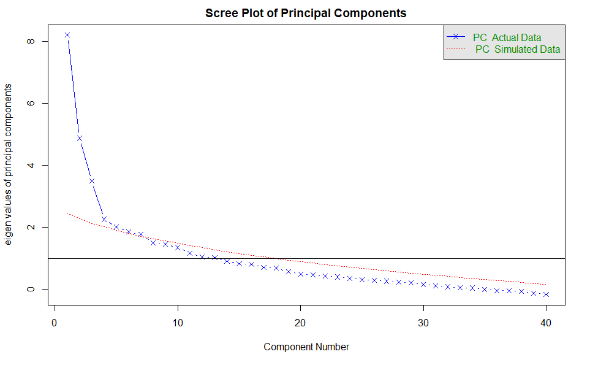

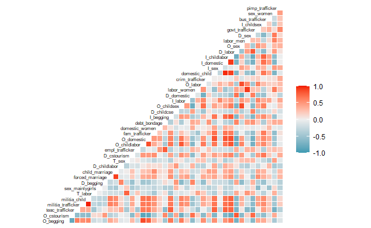

```
Matrix was not positive definite, smoothing was done
```

```
Principal Components Analysis
Call: principal(r = trafpresCor_pca_apr18, nfactors = 11, residuals = TRUE,
    rotate = "varimax", scores = TRUE)
Standardized loadings (pattern matrix) based upon correlation matrix
```

|  | RC1 | RC3 | RC6 | RC2 | RC5 | RC10 | RC7 | RC9 | RC8 | RC11 | RC4 | h2 | u2 | com |
| --- | --- | --- | --- | --- | --- | --- | --- | --- | --- | --- | --- | --- | --- | --- |
| O_begging | 0.13 | 0.77 | -0.02 | 0.02 | -0.16 | 0.04 | 0.19 | 0.01 | -0.04 | -0.10 | 0.10 | 0.6986564 | 0.30134358 | 1.374768 |
| O_cstourism | -0.28 | -0.56 | 0.22 | 0.19 | 0.05 | 0.29 | 0.17 | -0.06 | -0.22 | -0.08 | -0.19 | 0.6882300 | 0.31177003 | 3.891505 |
| teac_trafficker | 0.61 | 0.34 | -0.26 | -0.16 | -0.11 | 0.20 | 0.20 | -0.26 | -0.25 | -0.21 | 0.06 | 0.8511072 | 0.14889284 | 4.162993 |
| militia_trafficker | 0.27 | 0.23 | 0.14 | -0.03 | 0.07 | 0.09 | 0.24 | 0.82 | -0.02 | 0.08 | 0.07 | 0.8981572 | 0.10184284 | 1.739302 |
| militia_child | 0.27 | 0.27 | 0.15 | 0.01 | 0.04 | 0.07 | 0.26 | 0.82 | 0.03 | 0.08 | -0.01 | 0.9201393 | 0.07986066 | 1.825964 |
| T_labor | 0.09 | -0.09 | 0.03 | 0.33 | -0.01 | 0.02 | -0.02 | 0.06 | 0.83 | -0.12 | 0.04 | 0.8465076 | 0.15349240 | 1.443336 |
| sex_mainlygirls | -0.09 | 0.07 | -0.05 | -0.07 | 0.14 | 0.08 | -0.10 | -0.01 | 0.00 | -0.07 | -0.80 | 0.7023978 | 0.29760224 | 1.200615 |
| D_begging | 0.01 | -0.10 | -0.09 | 0.05 | -0.09 | 0.71 | 0.12 | 0.02 | -0.11 | -0.25 | 0.11 | 0.6402448 | 0.35975518 | 1.561332 |
| forced_marriage | 0.16 | 0.10 | 0.03 | 0.10 | 0.16 | -0.07 | 0.84 | 0.22 | 0.05 | -0.03 | 0.11 | 0.8403315 | 0.15966847 | 1.424589 |
| child_marriage | 0.15 | 0.08 | 0.11 | -0.01 | 0.07 | 0.06 | 0.89 | 0.11 | 0.15 | 0.20 | 0.09 | 0.9143767 | 0.08562333 | 1.355824 |

[output cut: 30 more lines]

```
                       RC1  RC3  RC6  RC2  RC5 RC10  RC7  RC9  RC8 RC11
SS loadings           4.73 3.82 2.76 2.76 2.76 2.67 2.42 2.34 1.97 1.93
Proportion Var        0.12 0.10 0.07 0.07 0.07 0.07 0.06 0.06 0.05 0.05
Cumulative Var        0.12 0.21 0.28 0.35 0.42 0.49 0.55 0.61 0.66 0.70
Proportion Explained  0.16 0.13 0.09 0.09 0.09 0.09 0.08 0.08 0.07 0.06
Cumulative Proportion 0.16 0.29 0.38 0.47 0.56 0.65 0.73 0.81 0.88 0.94
                       RC4
SS loadings           1.78
Proportion Var        0.04
Cumulative Var        0.75
Proportion Explained  0.06
Cumulative Proportion 1.00

Mean item complexity =  2.5
Test of the hypothesis that 11 components are sufficient.

The root mean square of the residuals (RMSR) is  0.05

Fit based upon off diagonal values = 0.96
```

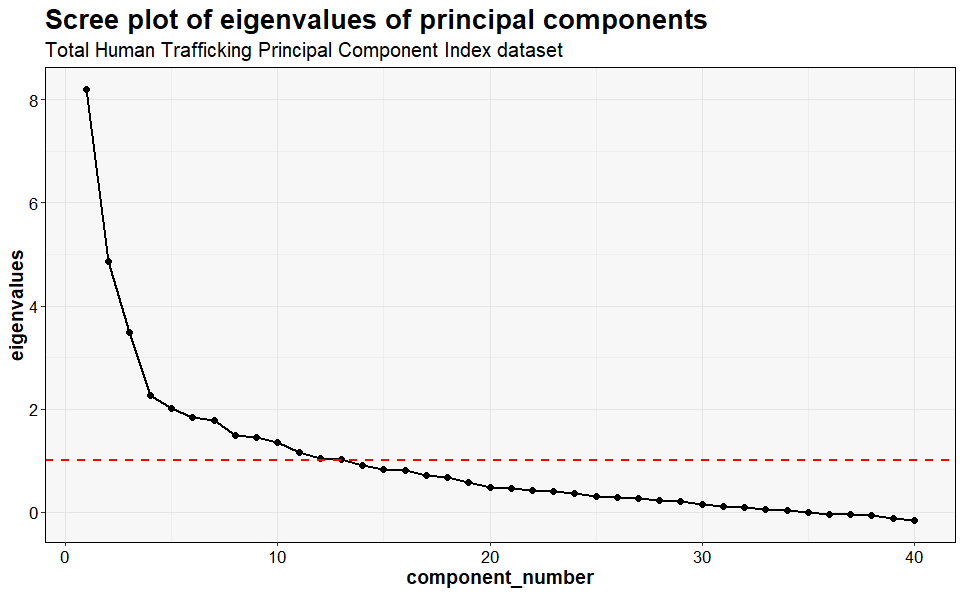

```r
pca_scree_vals <- data.frame(PCAscree_apr18$pc.values) %>%
  rename(eigenvalues = PCAscree_apr18.pc.values) %>%
  mutate(component_number = seq.int(1, 40, 1))

pca_scree_vals %>%
  ggplot(., aes(x=component_number,
                y=eigenvalues)) +
  geom_point(size=2) +
  geom_line(size=1) +
  ggtitle('Scree plot of eigenvalues of principal components',
          subtitle = 'Total Human Trafficking Principal Component Index dataset') +
  geom_hline(yintercept = 1, linetype = 'dashed', lwd=1, color='red') +
  my.theme
```

## Index building

```r
#identifying and removing multiple CY observations
mult_CY_obs <- HTCdata_v2 %>%
  group_by(country, year) %>%
  summarise(count = n()) %>%
  arrange(desc(count)) %>%
  mutate(country_year = paste(country, year, sep="_")) %>%
  filter(count > 1) %>%
  ungroup() %>%
  select(country_year)
```

```r
HTCPI_total_df <- HTCdata_index_mar18 %>%
  group_by(country, year) %>%
  summarise(HTCPI = sum(HTCPI_subindex_score, na.rm = TRUE))
```

## Plotting

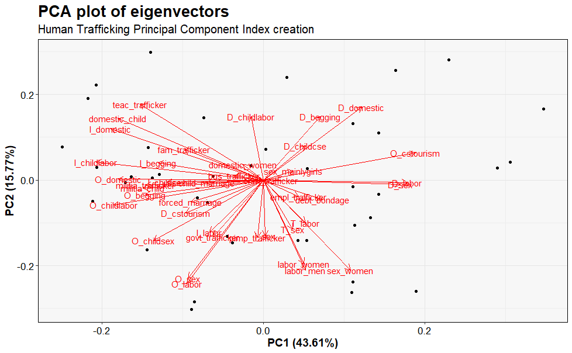

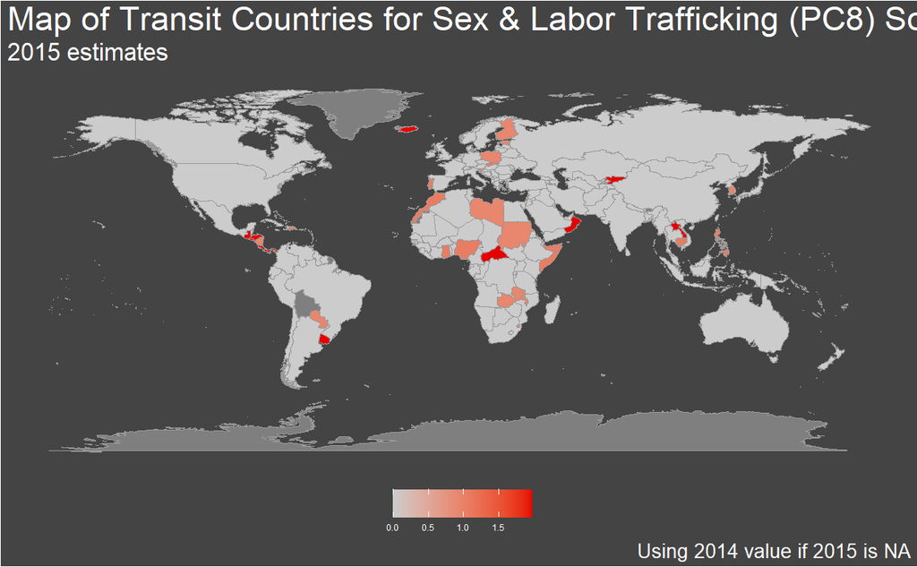

## Sum coding and rank of sum coding

```r
pca_index_analysis_of_rank_2 <- HTCdata_v2 %>%
  mutate(country_year = paste(country, year, sep="_")) %>%
  filter(!country_year %in% mult_CY_obs$country_year) %>%
  mutate(country = recode(country, 'Antigua and Barbuda' = 'Antigua',
                          'Brunei Darussalam' = 'Brunei',
                          "Côte d'Ivoire" = 'Ivory Coast',
                          'Congo, the Democratic Republic of the' = 'Democratic Republic of the Congo',
                          'Congo' = 'Republic of Congo',
                          'Cabo Verde' = 'Cape Verde',
                          'Curaçao' = 'Curacao',
                          'Micronesia, Federated States of' = 'Micronesia',
                          'United Kingdom' = 'UK',
                          'Iran, Islamic Republic of' = 'Iran',
                          'Korea, Republic of' = 'South Korea',
                          "Lao People's Democratic Republic" = 'Laos',
                          'Moldova, Republic of' = 'Moldova',
                          'Macedonia, the former Yugoslav Republic of' = 'Macedonia',
                          "Korea, Democratic People's Republic of" = 'North Korea',
                          'Syrian Arab Republic' = 'Syria',
                          'Taiwan, Province of China' = 'Taiwan',
                          'Tanzania, United Republic of' = 'Tanzania',
                          'United States of America' = 'USA',
                          'Venezuela, Bolivarian Republic of' = 'Venezuela',
                          'Viet Nam' = 'Vietnam',
                          'Russian Federation' = 'Russia')) %>%
  filter(year == 2014) %>%
  select(-country_year) %>%
  gather(var, val, 3:42) %>%
  group_by(country, year) %>%
  summarise(sum_val = sum(val, na.rm=TRUE)) %>%
  arrange(desc(sum_val)) %>%
  ungroup() %>%
  #min_rank() and dense_rank() should both be explored
  #min_rank() allows for ties but gives gaps between ranking
  #dense_rank() allows for ties but does not give gaps between rankings
  mutate(rank_sum = ifelse(is.na(sum_val), NA, min_rank(desc(sum_val)))) %>%
  left_join(x=.,
            y=final_df,
            by=c('country' = 'country', 'year' = 'year')) %>%
  mutate(rank_HTCPI = ifelse(is.na(HTCPI), NA, min_rank(desc(HTCPI)))) %>%
  mutate(rank_difference = ifelse(is.na(rank_HTCPI), NA, rank_HTCPI - rank_sum)) %>%
  mutate(`Absolute value of rank difference` = abs(rank_difference),
         `Valence of rank difference` = ifelse(rank_difference >0, 'Positive',
                                        ifelse(rank_difference <0, 'Negative', 'Zero')))
```

### Maps

```r
colnames(test_pca_index_analysis_of_rank)
```

```
 [1] "country"
 [2] "year"
 [3] "sum_val"
 [4] "rank_sum"
 [5] "HTCPI"
 [6] "Countries of Origin for Child Trafficking (PC3)"
 [7] "Destination of Child Sex Tourism Trafficking (PC11)"
 [8] "Destination of Child Trafficking (PC10)"
 [9] "Domestic Servitude Trafficking (PC6)"
[10] "Forced Marriage Trafficking (PC7)"
[11] "General Labor Trafficking (PC2)"
[12] "Internal Forced Child Labor Trafficking (PC1)"
[13] "Internal Sex Trafficking (PC5)"
[14] "Militia-related Trafficking (PC9)"
[15] "Transit Countries for Sex & Labor Trafficking (PC8)"
[16] "rank_HTCPI"
[17] "rank_difference"
[18] "Absolute value of rank difference"
[19] "Valence of rank difference"
```

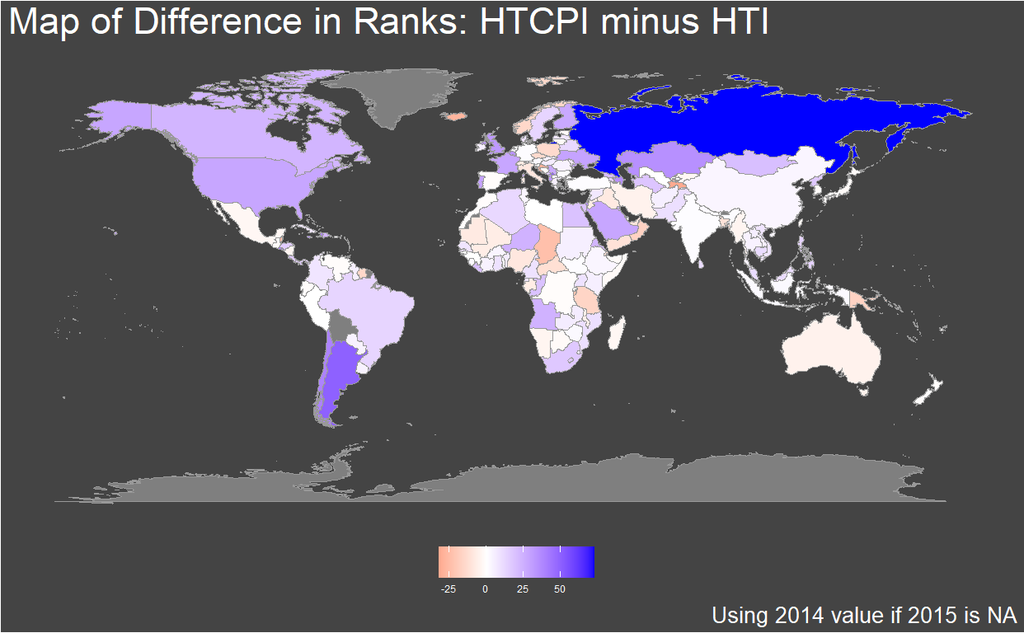

### Scatterplots

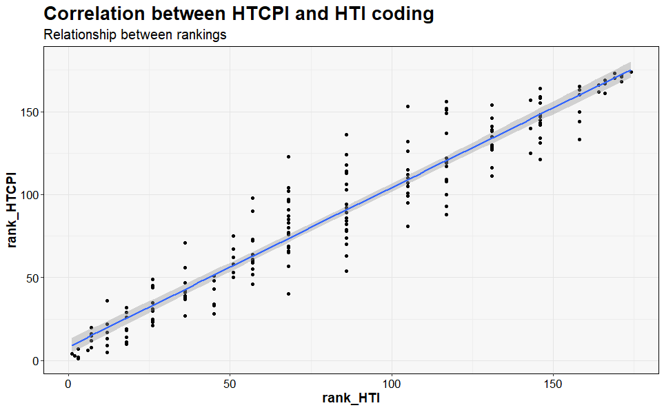

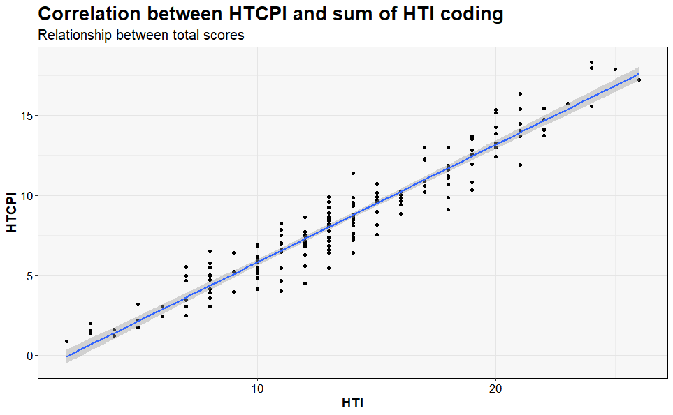

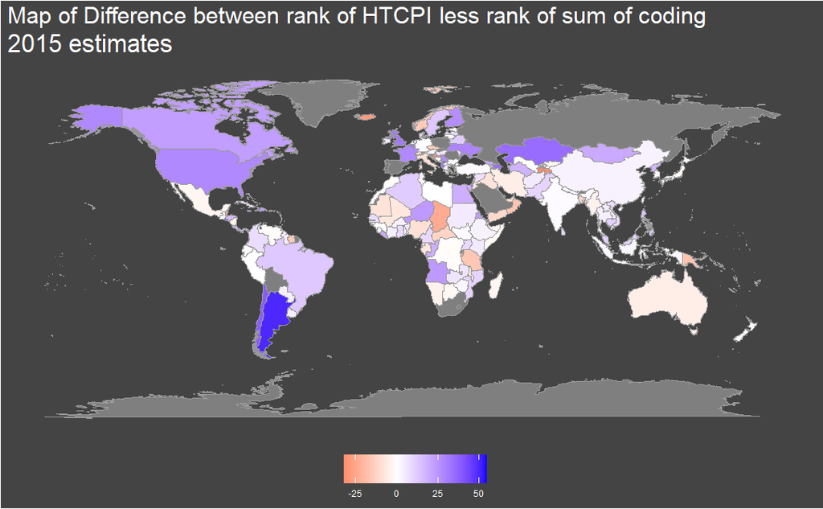

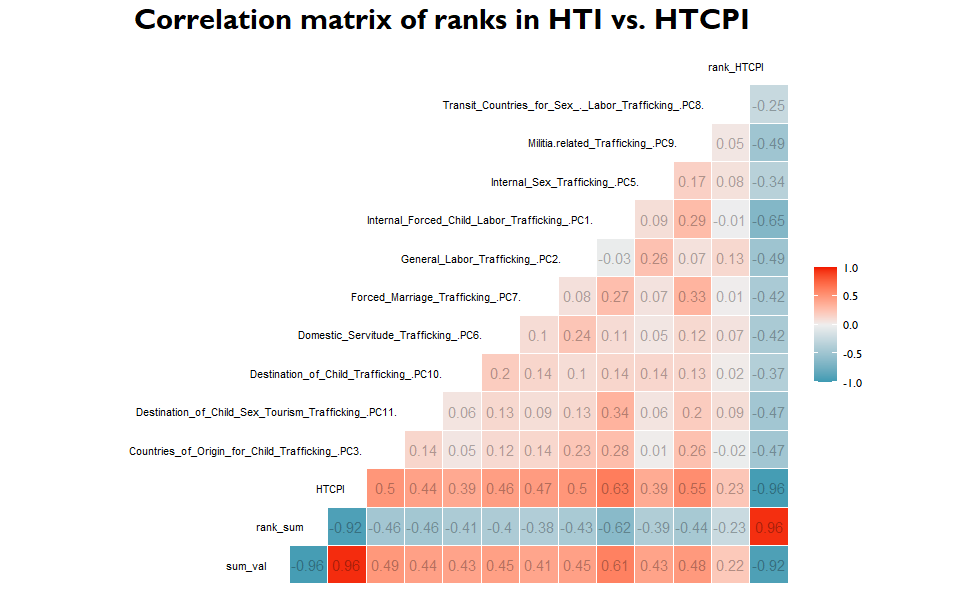